# Clase 4

Domenech Burin, Laia

03 junio, 2022

## El mundo tidyverse: vol 2

- La clase pasada vimos algunas de las funciones que vienen incluidas en el paquete tidyverse. Estuvimos trabajando con operaciones sobre columnas y filtrados.
- La clase de hoy vamos a seguir con dplyr, viendo cómo usar funciones para crear medidas resumen, unir dataframes y “pivotearlos”.
- También vamos a introducir el paquete `lubridate` para trabajar con formatos de fecha.

Primero, vamos a importar la base de homicidios dolosos y el paquete tidyverse:

```r
library(tidyverse)

df <- readxl::read_excel("./data/Integrado_HD_base_usuaria_2017-2020.xlsx")
```

## `group_by` + `summarize()`

- `group_by` cambia la unidad de análsis del dataset a grupos. Así, al llamar a cualqyuer verbo de `dplyr` se aplica “por grupo”,
- combinándolo con `summarize()`, nos permite hacer una tabla con una medida resumen de las variables que querramos.

Por ejemplo, podemos hacer el conteo de frecuencias de los tipos de arma utilizadas:

```r
df %>%
    group_by(clase_arma) %>%
    summarize(n = n())
```

```
## # A tibble: 11 × 2
##    clase_arma                          n
##    <chr>                           <int>
##  1 Ahorcamiento / asfixia            551
##  2 Arma blanca                      5880
##  3 Arma de fuego                   10277
##  4 Arrollamiento por rodado o tren    82
##  5 Envenenamiento                     19
##  6 Golpes                            808
##  7 Objeto contundente               1266
##  8 Otra arma o mecanismo              85
##  9 Precipitación al vacío             32
## 10 Quemaduras                        338
## 11 Sin determinación                1179
```

El tipo de arma utilizado según la provincia

```r
df %>%
    group_by(provincia, clase_arma) %>%
    summarize(n = n())
```

```
## # A tibble: 192 × 3
## # Groups:   provincia [24]
##    provincia    clase_arma                          n
##    <chr>        <chr>                           <int>
##  1 BUENOS AIRES Ahorcamiento / asfixia            117
##  2 BUENOS AIRES Arma blanca                      1882
##  3 BUENOS AIRES Arma de fuego                    4669
##  4 BUENOS AIRES Arrollamiento por rodado o tren    32
##  5 BUENOS AIRES Golpes                            174
##  6 BUENOS AIRES Objeto contundente                447
##  7 BUENOS AIRES Otra arma o mecanismo              28
##  8 BUENOS AIRES Precipitación al vacío              8
##  9 BUENOS AIRES Quemaduras                        129
## 10 BUENOS AIRES Sin determinación                 634
## # … with 182 more rows
```

La media de víctimas según el año:

```r
df %>%
    group_by(anio) %>%
    summarize(mean_vic = round(mean(cant_vic, na.rm = TRUE)), mean_inc = round(mean(cant_inc,
        na.rm = TRUE)))
```

```
## # A tibble: 4 × 3
##    anio mean_vic mean_inc
##   <dbl>    <dbl>    <dbl>
## 1  2017        1        1
## 2  2018        1        1
## 3  2019        1        1
## 4  2020        1        2
```

- Si quiero seguir trabajando con el objeto que está agrupado sin esos grupos, tengo que usar la función `ungroup()`

## `pivot_longer` y `pivot_wider`

- `pivot_longer` “alarga” los datos convirtiendo columnas a filas. Tiene los siguientes parámetros: + `cols`: elijo las columnas que quiero pasar a filas + `names_to`: indico el nombre de la columna que va a contener las variables elegidas + `values_to`: indico el nombre de la columna que va a contener los valores de las variables

```r
medidas_resumen <- df %>%
    group_by(provincia) %>%
    summarise(media_inc = mean(cant_inc, na.rm = TRUE), mediana_inc = median(cant_inc,
        na.rm = TRUE)) %>%
    select(provincia, media_inc, mediana_inc)

pivot_longer_resumen <- medidas_resumen %>%
    pivot_longer(cols = c(media_inc, mediana_inc), names_to = "variable", values_to = "valor")

medidas_resumen
```

```
## # A tibble: 24 × 3
##    provincia              media_inc mediana_inc
##    <chr>                      <dbl>       <dbl>
##  1 BUENOS AIRES                1.34           1
##  2 CATAMARCA                   1.38           1
##  3 CHACO                       2.32           2
##  4 CHUBUT                      1.48           1
##  5 CIUDAD DE BUENOS AIRES      1.30           1
##  6 CORDOBA                     1.20           1
##  7 CORRIENTES                  1.71           1
##  8 ENTRE RIOS                  1.32           1
##  9 FORMOSA                     1.23           1
## 10 JUJUY                       2.60           1
## # … with 14 more rows
```

```r
pivot_longer_resumen %>%
    pivot_wider(id_cols = provincia, names_from = variable, values_from = valor)
```

```
## # A tibble: 24 × 3
##    provincia              media_inc mediana_inc
##    <chr>                      <dbl>       <dbl>
##  1 BUENOS AIRES                1.34           1
##  2 CATAMARCA                   1.38           1
##  3 CHACO                       2.32           2
##  4 CHUBUT                      1.48           1
##  5 CIUDAD DE BUENOS AIRES      1.30           1
##  6 CORDOBA                     1.20           1
##  7 CORRIENTES                  1.71           1
##  8 ENTRE RIOS                  1.32           1
##  9 FORMOSA                     1.23           1
## 10 JUJUY                       2.60           1
## # … with 14 more rows
```

```r
df %>%
    group_by(provincia, clase_arma) %>%
    summarize(n = n()) %>%
    pivot_wider(id_cols = provincia, names_from = clase_arma, values_from = n)
```

```
## # A tibble: 24 × 12
## # Groups:   provincia [24]
##    provincia     `Ahorcamiento …` `Arma blanca` `Arma de fuego` `Arrollamiento…`
##    <chr>                    <int>         <int>           <int>            <int>
##  1 BUENOS AIRES               117          1882            4669               32
##  2 CATAMARCA                   10            24              21               NA
##  3 CHACO                       19           317             305                5
##  4 CHUBUT                      19           185             124               NA
##  5 CIUDAD DE BU…               41           283             472                9
##  6 CORDOBA                     50           250             480                2
##  7 CORRIENTES                   9           146              92                4
##  8 ENTRE RIOS                  19           187             213               NA
##  9 FORMOSA                     10           181              39                2
## 10 JUJUY                       31            77              52               NA
## # … with 14 more rows, and 7 more variables: Golpes <int>,
## #   `Objeto contundente` <int>, `Otra arma o mecanismo` <int>,
## #   `Precipitación al vacío` <int>, Quemaduras <int>,
## #   `Sin determinación` <int>, Envenenamiento <int>
```

## `join()`

- Esta función sirve para unir un dataframe x con un dataframe y a partir de un identificador común. Existen distintos tipos de join:
  - `inner_join():` incluye todas las filas que estén en x e y.
  - `left_join():` incluye todas las filas que estén en x.
  - `right_join():` incluye todas las filas que estén en y.
  - `full_join():` incluye todas las filas que estén en x o y.

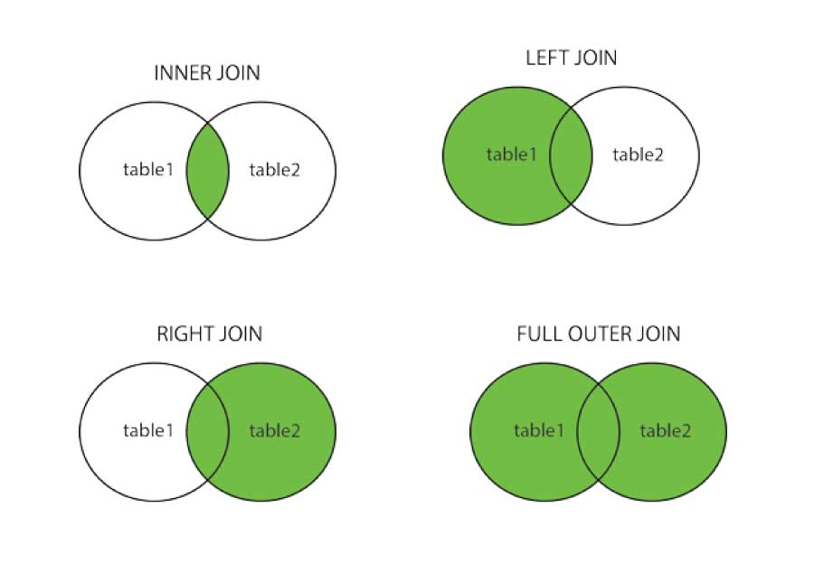

Por ejemplo, supongamos que queremos agregar a esta base de datos la información geográfica de cada provincia para poder marcarla en un mapa. Vamos a usar una base de datos del [IGN](https://www.ign.gob.ar/NuestrasActividades/InformacionGeoespacial/CapasSIG).

```r
geo <- sf::read_sf("./data/pxlocdatos.shp") %>%
    select(codpcia, coddpto, geometry)
head(geo)
```

```
## Simple feature collection with 6 features and 2 fields
## Geometry type: POINT
## Dimension:     XY
## Bounding box:  xmin: 3742758 ymin: 5851484 xmax: 4198824 ymax: 6144078
## Projected CRS: POSGAR_94_Argentina_3
## # A tibble: 6 × 3
##   codpcia coddpto          geometry
##   <chr>   <chr>         <POINT [m]>
## 1 02      000     (4198824 6144078)
## 2 06      007     (3787955 5880832)
## 3 06      007     (3755080 5851763)
## 4 06      007     (3745278 5866646)
## 5 06      007     (3815560 5859954)
## 6 06      007     (3742758 5851484)
```

```r
df_merged <- geo %>%
    left_join(df, by = c(codpcia = "Cod_INDEC_Prov", coddpto = "codigo_departamento"))

colnames(df_merged)
```

```
##  [1] "codpcia"                          "coddpto"
##  [3] "geometry"                         "Id_hecho"
##  [5] "federal"                          "provincia"
##  [7] "Cod_INDEC"                        "departamento"
##  [9] "anio"                             "mes"
## [11] "radio_censal"                     "tipo_lugar"
## [13] "otro_tipo_lugar"                  "clase_arma"
## [15] "otro_clase_arma"                  "en_ocasion_otro_delito"
## [17] "otro_en_ocasion_otro_delito"      "motivo_origen_registro"
## [19] "otro_motivo_origen_registro"      "fecha_hecho"
## [21] "hora_hecho"                       "tipo_persona_id"
## [23] "tipo_persona"                     "sexo_victima"
## [25] "identidad_genero_victima"         "tr_edad_victima"
## [27] "clase_victima"                    "otro_clase_victima"
## [29] "situacion_ocupacional_victima"    "otro_situacion_ocupacional_victi"
## [31] "otro_identidad_genero_victima"    "sexo_inculpado"
## [33] "identidad_genero_inculpado"       "otro_identidad_genero_inculpado"
## [35] "tr_edad_inculpado"                "clase_inculpado"
## [37] "otro_clase_inculpado"             "relacion_inculpado_victima"
## [39] "relacion_victima_inculpado"       "tipo_hecho_segun_victima"
## [41] "observaciones"                    "cant_inc"
## [43] "cant_vic"
```

## Fechas

- Tenemos tres tipos de variables de tiempo principales en R:
  - **Date:** (Sólo Año, Mes y Día).
  - **Time:** (Un horario, sin especificar de que día es)
  - **Date-time:** (Año, Mes, Día y horario)

Veamos el formato de nuestras fechas en el dataframe que estamos trabajando:

```r
class(df$fecha_hecho)
```

```
## [1] "POSIXct" "POSIXt"
```

Este es un formato de dato que manejar la hora y la fecha. El almacenamiento interno de una fecha en formato POSIXct es el número de segundos transcurridos desde el 1 de enero de 1970. Para fechas anteriores se usan números negativos.

### `lubridate`

Es un paquete que está hecho para hacer más fácil el trabajo con fechas y horarios. Algunas de sus funcionalidades principales son:

- Construir variables de tipo fecha a partir de números o caracteres
- Extraer información de variables ya constituídas como fechas
- Realizar operatorias con fechas (ej: calculo de distancias temporales entre dos registros)

```r
library(lubridate)
```

Mediante la combinacion de los caracteres **dmy_hms** que representan a día(d), mes(m), año(y), hora(h), minuto(m) y segundo(s) podemos convertir un número (o un string) hacia una fecha.

```r
fecha_1 <- "30 de abril 2021"

class(fecha_1)
```

```
## [1] "character"
```

```r
fecha_1_formato <- dmy(fecha_1)

class(fecha_1_formato)
```

```
## [1] "Date"
```

También podría crear una fecha con horas, minutos y segundos:

```r
fecha_2 <- "2020/08/04 13:40:43"

fecha_2 <- ymd_hms(fecha_2)
class(fecha_2)
```

```
## [1] "POSIXct" "POSIXt"
```

Y para formatos menos estandarizados, se puede usar la función `parse_date_time()`

```r
fecha_3 <- c("Oct 4", "May 20", "Feb 15")

parse_date_time(fecha_3, orders = "md")
```

```
## [1] "2022-10-04 UTC" "2022-05-20 UTC" "2022-02-15 UTC"
```

También podemos **extraer** información de las fechas. Por ejemplo, podemos desagregar la fecha de trámite en:

- día (de la semana y el número)
- mes (con nombre o número)
- año

```r
data_ejemplo_fecha <- df %>%
    select(fecha_hecho) %>%
    mutate(dia = wday(fecha_hecho), dia_semana = wday(fecha_hecho, label = TRUE),
        mes = month(fecha_hecho), mes_nombre = month(fecha_hecho, label = TRUE),
        anio = year(fecha_hecho))

head(data_ejemplo_fecha)
```

```
## # A tibble: 6 × 6
##   fecha_hecho           dia dia_semana   mes mes_nombre  anio
##   <dttm>              <dbl> <ord>      <dbl> <ord>      <dbl>
## 1 2017-01-14 00:00:00     7 sáb            1 ene         2017
## 2 2017-01-14 00:00:00     7 sáb            1 ene         2017
## 3 2017-01-14 00:00:00     7 sáb            1 ene         2017
## 4 2017-01-14 00:00:00     7 sáb            1 ene         2017
## 5 2017-01-07 00:00:00     7 sáb            1 ene         2017
## 6 2017-01-07 00:00:00     7 sáb            1 ene         2017
```

Finalmente, podemos hacer distintas operaciones sobre las fechas. Por ejemplo, podemos calcular la cantidad de tiempo que pasó entre el primer registro de trámite y el último:

```r
max(df$fecha_hecho) - min(df$fecha_hecho)
```

```
## Time difference of 1460 days
```

Podemos agregarle días, meses, o años a una fecha:

```r
fecha_4 <- df$fecha_hecho[4]

fecha_4
```

```
## [1] "2017-01-14 UTC"
```

```r
fecha_4 + days(4)
```

```
## [1] "2017-01-18 UTC"
```

```r
fecha_4 + months(5)
```

```
## [1] "2017-06-14 UTC"
```

```r
fecha_4 + years(2)
```

```
## [1] "2019-01-14 UTC"
```

## Programación funcional

En este material veremos algunas herramientas un poco más avanzadas que sirven para escalar procedimientos que vimos anteriormente y/o para automatizar (parte de) nuestro trabajo. La idea es un primer acercamiento a herramientas que evitan tener que constantemente copiar nuestro código y modificar algunos paramentos o variables, cada vez que queramos realizar procedimientos parecidos.

### if

- La función *if* se utilizará para correr código condicionalmente.
- Su funcionamiento es el siguiente:

`if(condicion){codigo a ejecutar si se cumple la condición}`

```r
if (10 + 5 == 15) {
    print("Perfecto")
}
```

```
## [1] "Perfecto"
```

```r
if (10 + 5 != 148.24) {
    print("Error")
}
```

```
## [1] "Error"
```

### if + else

- La función **if** también puede utilizarse para indicar la ejecución de uno u otro fragmentos de código según se cumpla o no una condición. Para ello, agregamos **`else{}`** y el código a ejecutar en caso de NO cumplimiento de la condición, de la siguiente manera:

`if(condicion){codigo a ejecutar si se cumple la condición} else {codigo a ejecutar si NO se cumple la condición}`

- Veamos un ejemplo. Queremos que nuestro código nos indique si la fecha de ejecución del código coincide con la de la última actualización de la base de datos. Caso contrario, queremos que se nos indique la diferencia de tiempo entre ambas.

```r
ultima.actualiz.base <- ymd(max(df$fecha_hecho))
ultima.actualiz.base
```

```
## [1] "2020-12-31"
```

- ¿Es dicha fecha igual a la fecha actual de ejecución del código? Para ello podemos usar la función **Sys.Date()** de RBase

```r
if (ultima.actualiz.base == Sys.Date()) {
    "Datos al día de hoy"
} else {
    Sys.Date() - ultima.actualiz.base
}
```

```
## Time difference of 519 days
```

### loops

- Los **loops** son estructuras de código que sirven para repetir un conjunto de operaciones en un intervalo determinado. Por ejemplo:

```r
for (x in 1:10) {
    print(x * 5)
}
```

```
## [1] 5
## [1] 10
## [1] 15
## [1] 20
## [1] 25
## [1] 30
## [1] 35
## [1] 40
## [1] 45
## [1] 50
```

- La lógica del loop es:
  - `x` es leído como cada uno de los valores del vector `1:10`
  - como el primer valor de la secuencia que definimos es 1, el loop empieza reemplazando el 1 por x y corre todo lo que está entre llaves `{}`.
- Otra forma de escribir lo que está haciendo el loop es:

```r
(1:10) * 5
```

```
##  [1]  5 10 15 20 25 30 35 40 45 50
```

- Los `while` loops empiezan testeando una condición. Si la condición es verdadera ejecutan el bloque de código debajo del `while`. Una vez que se ejecuta el bloque, se vuelve a testar la condición.
- Cuando la condición se hace falsa sale del loop.

```r
> count <- 0
> while (count < 4) {
+     print(count)
+     count <- count + 1
+ }
## [1] 0
## [1] 1
## [1] 2
## [1] 3
```

- En los loops existen **estructuras de control** para saltear partes del mismo o salir de él aún cuando la condición que definimos no se cumpla.
  - `next` se usa para saltear una iteración en un loop

```r
for (i in 1:6) {
    if (i <= 2) {
        next
    }
    print(i)
}
```

```
## [1] 3
## [1] 4
## [1] 5
## [1] 6
```

- `break` se usa para salir de un loop (aún cuando una condición no se cumpla).

```r
for (i in 1:6) {
    if (i > 2) {
        break
    }
    print(i)
}
```

```
## [1] 1
## [1] 2
```

Una herramienta que vamos a utilizar mucho en estos casos es la función *seq()*, que permite generar una secuencia de números (que vamos a utilizar para iterar).

```r
vector_ej <- c(1, 2, 7, 5, 8, 9)

seq(length(vector_ej))
```

```
## [1] 1 2 3 4 5 6
```

### Aplicación sobre una base de datos

Veamos cómo puede ser útil para un procesamiento.

Si tenemos una base de datos con información sobre distintos tipos de población, podemos querer generar una medida resumen para cada segmento de la población.

```r
vector_valores <- unique(df$provincia) #Creo un vector con los distintos valores que puede adoptar la columna "provincia"

datos_graf <- list() #En esta lista vamos a guardar nuestros resultados

for (valor in (seq(length(vector_valores)))) { #Realizo la iteración secuencialmente sobre todos los valores del vector

  tabla_resumen <- df %>% #Creo la tabla resumen
    filter(provincia == vector_valores[valor]) %>%
    filter(en_ocasion_otro_delito != "Sin determinación") %>%
    group_by(departamento, en_ocasion_otro_delito) %>%
    summarise(n = n(),
              provincia = unique(provincia))  %>%
    pivot_wider(id_cols= c(departamento, provincia),
                            names_from = en_ocasion_otro_delito,
                            values_from = n)

  datos_graf[[valor]] <-  tabla_resumen #Asigno la tabla a un elemento de la lista

}
```

Veamos el resultado de una de las tablas que generamos:

```r
datos_graf[[8]]
```

```
## # A tibble: 10 × 5
## # Groups:   departamento [10]
##    departamento provincia `Sí Robo` `No fue en ocasión de otr…` `Si Otro Delito`
##    <chr>        <chr>         <int>                       <int>            <int>
##  1 9 de Julio   SAN JUAN          3                          NA               NA
##  2 Calingasta   SAN JUAN         NA                           2               NA
##  3 Capital      SAN JUAN          4                           2               NA
##  4 Caucete      SAN JUAN         15                           2               NA
##  5 Chimbas      SAN JUAN          6                          18                2
##  6 Jáchal       SAN JUAN         NA                           2               NA
##  7 Pocito       SAN JUAN          2                           2               NA
##  8 Rawson       SAN JUAN         10                          14               NA
##  9 Rivadavia    SAN JUAN         NA                          NA               12
## 10 Ullúm        SAN JUAN         NA                           2               NA
```

### Funciones

Retomamos lo introducido en la clase 2: la función es una forma de encapsular una serie de operaciones a las que vayamos a recurrir más de una vez, esta es su estructura general:

```r
fun_ej <- function(argumentos) {
    # [se hace algún cómputo]
}
```

En este caso, vamos a utilizar esta herramienta (junto con la iteración) para hacer que todas las columnas numéricas de las tablas generadas que tengan `NA` tomen el valor 0 y las tablas se guarden como archivos de Excel en la carpeta data.

```r
library(openxlsx)

funcion_procesamiento <- function(df){

        df <- df%>%
                mutate_at(vars(-c(departamento, provincia)),  ~ case_when(
                        is.na(.) ~ 0, #Modifico los NA por cero
                        TRUE ~ as.numeric(.) #Que los valores que no son NA se mantengan como en la columna original
                ))

        prov <- unique(df$provincia) #Creo un valor con el nombre de la provincia que está en la base

        write.xlsx(df, file = paste0("./data/delitos_", prov,".xlsx"), append = TRUE) #Lo escribo en un Excel
}
```

Finalmente, la aplicamos de forma iterativa:

```r
for (i in seq(length(datos_graf))) {

    funcion_procesamiento(datos_graf[[i]])  #Aplica la función sobre cada uno de los elementos de la lista data_graf

}
```